# 14. Linear Regression 1

Masahiko Asano

2025-09-08

- `R packages we use in this section`

```r
library(broom)
library(car)
library(jtools)
library(patchwork)
library(QuantPsyc)
library(sjPlot)
library(stargazer)
library(summarytools)
library(tidyverse)
```

# 1. Least Squares

## 1.1. Simple linear regression

- The method of least squares is a standard approach in regression analysis to approximate the solution of overdetermined systems by minimizing the sum of the squares of the residuals made in the results of every single equation.
- As shown in Section 13, correlation describes a linear relationship between two variables, x and y.

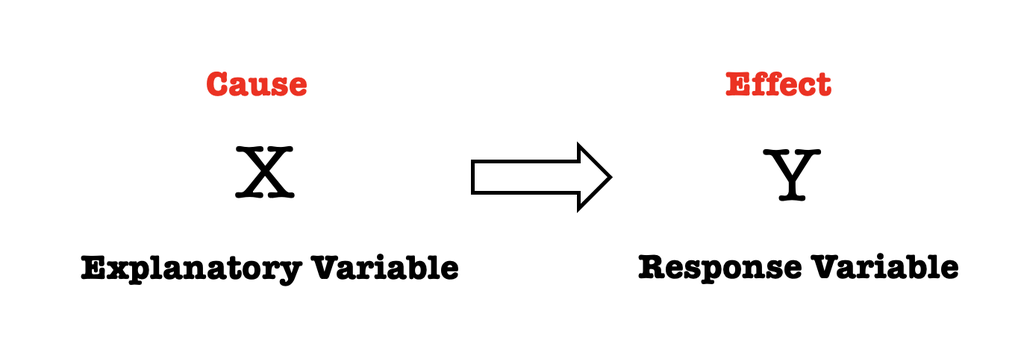

- Multiple notations on X and Y

| **X (Cause)** | **Y (Effect)** |
| --- | --- |
| `explanatory variable` | `response variable` |
| `independent variable` | `dependent variable` |
| `predictor` | `outcome` |
| `explanatory variable` | `explained variable` |
| `regressor` | `regressand` |

- This relationship is best characterized using the following linear model:

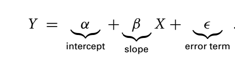

- Y is the outcome or response variable and X is the predictor or independent (explanatory) variable.
- Any line can be defined by the intercept $α$ and the slope parameter $β$.
- The intercept $α$ represents the average value of Y when X is zero.
- The slope $β$ measures the average increase in Y when X increases by one unit.
- The intercept and slope parameters are together called **coefficients**.
- The error (or disturbance) term, $ε$, allows an observation to deviate from a perfect linear relationship.
- Since the values of $α$ and $β$ in this equation are unknown to researchers, they must be estimated from the data.
- The estimates of parameters are indicated by “hats,” where $\hat{α}$ and $\hat{β}$ represent the estimates of $α$ and $β$, respectively.

$$\hat{Y} = \hat{α} +
\hat{β}x$$

- Most likely, the predicted value will not equal the observed value.
- The difference between the observed outcome and its predicted value is called the residual.
- Formally, we can write the residual as:

$$\hat{ε} = Y - \hat{Y}$$

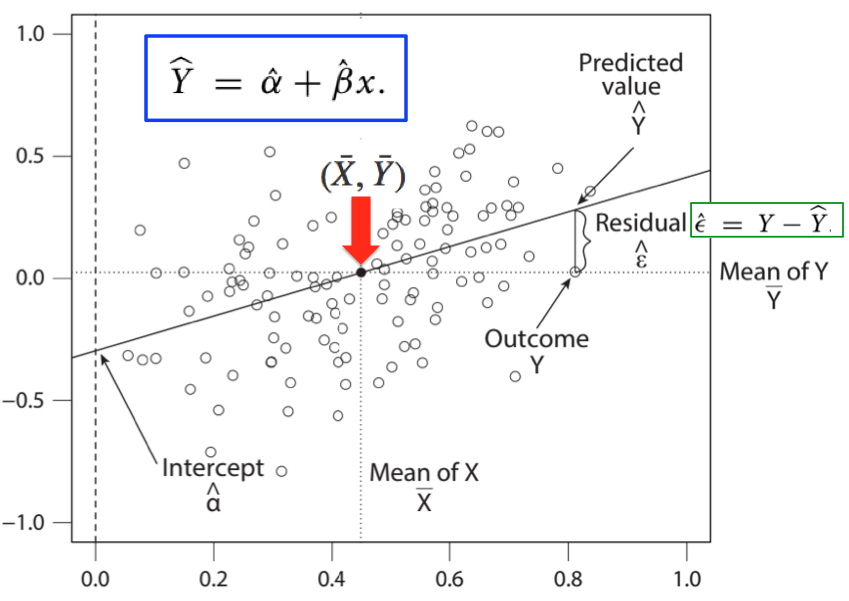

- The least squares estimates of intercept ($\hat{α}$) and slope ($\hat{β}$) parameters are given as follows:

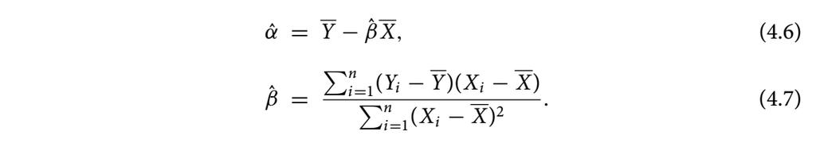

- The outcome variable, $\hat{Y}$, is given as follow:

$$\hat{Y} = \hat{α} + \hat{β}x$$

- Let’s check the values of $x$ and $Y$ when $x$ and $Y$ equal to their mean

$$\hat{Y} = \hat{α} +
\hat{β}\bar{X}$$

- Substitute $\hat{α}$ in (4.6) for $\hat{α}$ in the equation

$$\hat{Y} = (\bar{Y} - \hat{β}\bar{X})
+ \hat{β}\bar{X} = \bar{Y}$$

$$\bar{Y} - \hat{β}\bar{X} =
\hat{α}$$

- When the value of $x$ is equal to its mean ($\bar{X}$), the value of $Y$ is also equal to its mean ($\bar{Y}$).
- In the above plot, we see that this is indeed the case.
- The regression line runs through the intersection of the vertical and horizontal dotted lines, which represent the means of X and Y, $(\bar{X}, \bar{Y})$, respectively.
- A linear regression model always has zero average prediction error across all data points in the sample, but this does not necessarily mean that the linear regression model accurately represents the actual data-generating process.

*Source: Imai, Kosuke. Quantitative Social Science: An Introduction (p.141-147). Princeton University Press. Kindle.*

## 1.2 Manual calculation for $α$ and $β$

- Let’s calculate $α$ and $β$ by hand using the following dataset.
- [This video](https://youtu.be/GhrxgbQnEEU) helps you undersand how to calculate simple regression function by hand.
- Although the video uses the different dataset, it helps you have a better understanding of simple linear regression.

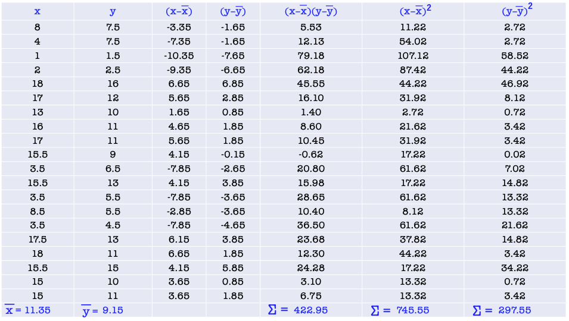

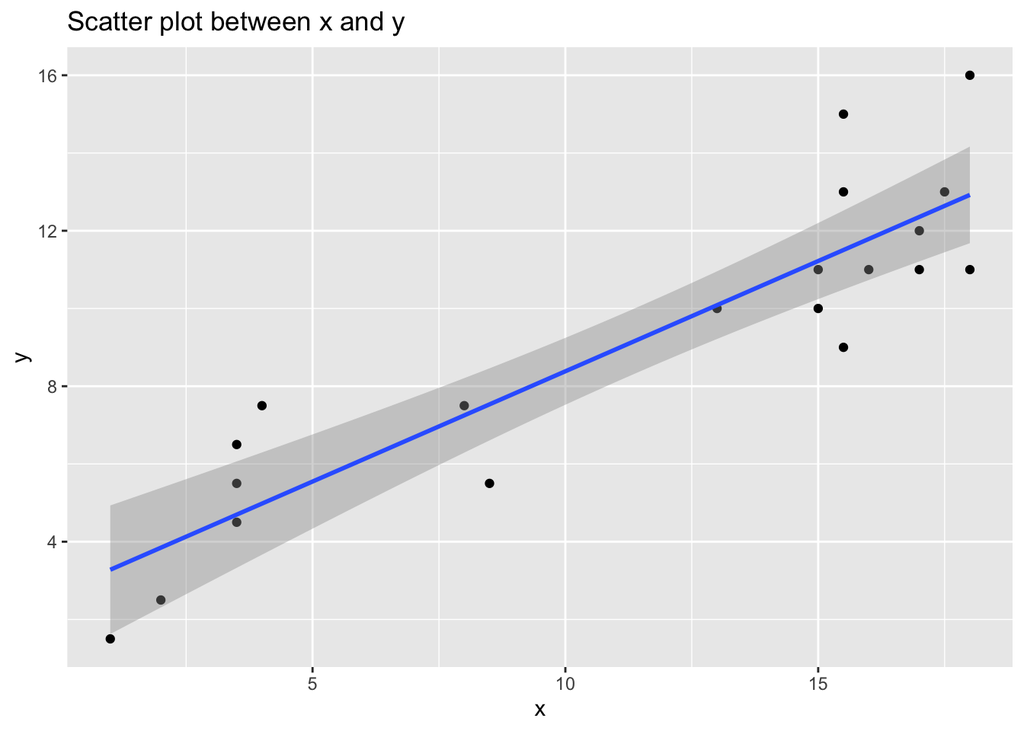

#### Regression equation

$$\hat{Y} = \hat{α} +
\hat{β}x$$

#### Slope ($β$) is difined as follows:

$$\hat{β} = r \frac{s_y}{s_x}$$

$r$ → ピアソンの相関係数  
$s_y$ → y の標準偏差  
$s_x$ → x の標準偏差

#### Intercept ($α$) is difined as follows:

$$\hat{α} = \bar{Y} -
β\bar{x}$$

- We can calculate Pearson correlation coefficient ($r$) as follows:

$$r =
\frac{\sum((x-\bar{x})(y-\bar{y}))}{\sqrt{Σ(x-\bar{x})^2Σ(y-\bar{y})^2}}=
\frac{422.95}{\sqrt{(745.55)(297.55)}}= \frac{422.95}{{471}}=
0.89$$

$s_y$ → y’s standard deviation

$$s_y=
\sqrt{\frac{Σ(y-\bar{y})^2}{{n-1}}}=
\sqrt{\frac{297.55}{{19}}}=3.96$$

$s_x$ → x’s standard deviasion

$$s_x=
\sqrt{\frac{Σ(x-\bar{x})^2}{{n-1}}}=
\sqrt{\frac{745.55}{{19}}}=6.26$$
$$\hat{β} = r \frac{s_y}{s_x}=
0.89*\frac{3.96}{6.26}=0.56$$

### $$\hat{Y}=2.79+0.56x$$

# 2. 4 Steps in empirical analysis

① Find a puzzle  
② Present your theory to explain the puzzle  
③ Present a testable hypothesis drawn from your theory  
④ Test your hypothesis with data

## 2.1 Find a puzzle

**Research Question**  
Why do we witness the differences on local government’s performance in Italy?

**Data**：

- `region`: Abbreviation of Italian local governments
- `gov_p`: Performance of Italian local governments

出典：飯田健『計量政治分析』p.28

## 2.2 Present your theory to explain the puzzle

**Theory: Social capital enhances local government’s performance.**

Source: Robert Putnam, (1994) Making Democracy Work: Civic Traditions in Modern Italy,  
Princeton, NJ: Princeton University Press)

**Theory**

- The differences on local government’s performance can be explained by the degree of social capital in each local government.
- Social capital can be defined as “the networks of relationships among people who live and work in a particular society, enabling that society to function effectively”.
- It involves the effective functioning of social groups through interpersonal relationships, a shared sense of identity, a shared understanding, shared norms, shared values, trust, cooperation, and reciprocity.
- Social capital help people build cooperation one another.  
  → **In the area with more social capital, the more people trust and cooperate one another, which leads to high quality government performance.**

## 2.4 Present a testable hypothesis drawn from your theory

**Hypothesis**：

- If the theory is correct, then we should see that the larger **civic community index (cc)** leads to higher **government performance (gov_p)**

# 3. Test your hypothesis with data

## 3.1 Data preparation(`putnam.csv`)

- Download [(putnam.csv)](http://www.ner.takushoku-u.ac.jp/masano/class_material/waseda/keiryo/Data/putnam.csv)
- Put the file (putnam.csv) into `data` folder in your `RProject` folder
- Load the data and name it `putnam`

```r
putnam <- read_csv("data/putnam.csv")
```

- Show the list of variables the data contains

```r
names(putnam)
```

```
[1] "region"   "gov_p"    "cc"       "econ"     "location"
```

**Data**：

| Types of variables | Variables | Details |
| --- | --- | --- |
| Outcome | `gov_p` | Performance of Italian local governments |
| Predictor | `region` | Abbreviation of Italian local governments |
| Predictor | `cc` | Civic Community Index |
| Predictor | `econ` | Economy Index (the larger, the better) |
| Predictor | `location` | Area dummy (`north`,`south`） |

- Check `putnum`

```r
DT::datatable(putnam)
```

|  | region | gov_p | cc | econ | location |
| --- | --- | --- | --- | --- | --- |
| 1 | Ab | 7.5 | 8 | 7 | south |
| 2 | Ba | 7.5 | 4 | 3 | south |
| 3 | Cl | 1.5 | 1 | 3 | south |
| 4 | Cm | 2.5 | 2 | 6.5 | south |
| 5 | Em | 16 | 18 | 13 | north |
| 6 | Fr | 12 | 17 | 14.5 | north |
| 7 | La | 10 | 13 | 12.5 | north |
| 8 | Li | 11 | 16 | 15.5 | north |
| 9 | Lo | 11 | 17 | 19 | north |
| 10 | Ma | 9 | 15.5 | 10.5 | north |

[output cut: 10 more lines]

## 3.2 Descriptive statistics

### 2 ways of showing desciptive statistics

- `summary()`

```r
summary(putnam)
```

```
    region              gov_p             cc              econ
 Length:20          Min.   : 1.50   Min.   : 1.000   Min.   : 2.50
 Class :character   1st Qu.: 6.25   1st Qu.: 3.875   1st Qu.: 6.25
 Mode  :character   Median :10.00   Median :15.000   Median :11.75
                    Mean   : 9.15   Mean   :11.350   Mean   :10.43
                    3rd Qu.:11.25   3rd Qu.:16.250   3rd Qu.:14.50
                    Max.   :16.00   Max.   :18.000   Max.   :19.00
   location
 Length:20
 Class :character
 Mode  :character
```

- `stargazer()`

```r
library("stargazer")
```

```r
stargazer(as.data.frame(putnam),
          type = "text",
          title = "Descriptve Statistics on Local Government's Performance",
          digits = 2)
```

```
Descriptve Statistics on Local Government's Performance
======================================
Statistic N  Mean  St. Dev. Min   Max
--------------------------------------
gov_p     20 9.15    3.96   1.50 16.00
cc        20 11.35   6.26   1.00 18.00
econ      20 10.43   5.08   2.50 19.00
--------------------------------------
```

## 3.3 Draw a scatter plot

- Draw a scatter plot between `cc` and `gov_p`

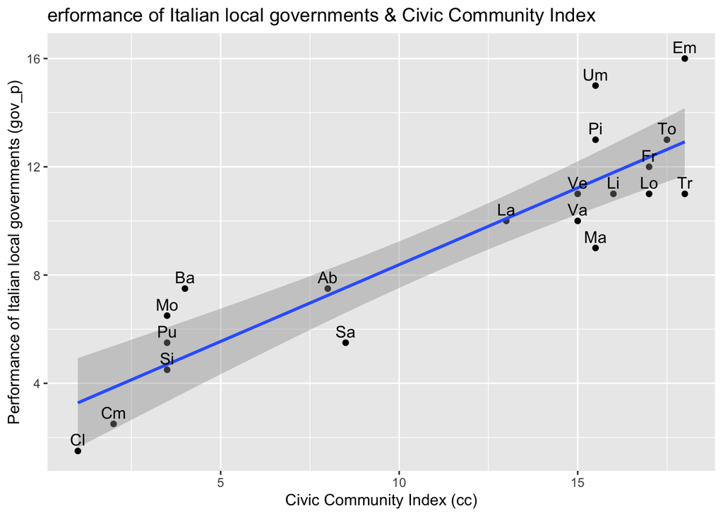

```r
ggplot(putnam, aes(cc, gov_p)) +
  geom_point() +
  labs(x = "Civic Community Index (cc)", y = "Performance of Italian local governments (gov_p)",
         title = "erformance of Italian local governments & Civic Community Index") +
  stat_smooth(method = lm) +
  geom_text(aes(y = gov_p + 0.2, label = region), size = 4, vjust = 0)
```

- Calculate the correlation coefficient between `gov_p` and `cc`

```r
cor.test(putnam$gov_p, putnam$cc)
```

```
    Pearson's product-moment correlation

data:  putnam$gov_p and putnam$cc
t = 8.6583, df = 18, p-value = 7.806e-08
alternative hypothesis: true correlation is not equal to 0
95 percent confidence interval:
 0.7558102 0.9593028
sample estimates:
      cor
0.8979883
```

- Correlation coefficient between `gov_p` and `cc` is 0.8979883
- A stronger correlation
- However, we need to use a regression analysis to seek for a causality between them

## 3.4 Simple Regression

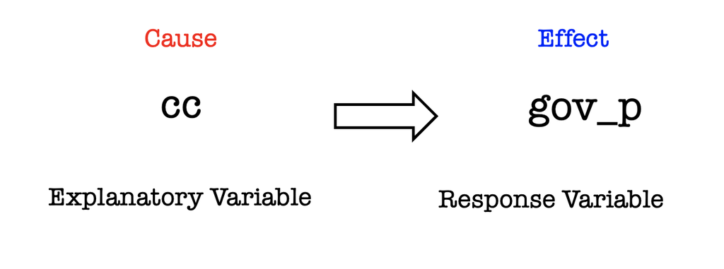

```r
Model_1<- lm(gov_p ~ cc, data = putnam)
```

### 3.4.1 How to show regression results

#### (1) `Summary()`

```r
summary(Model_1)
```

```
Call:
lm(formula = gov_p ~ cc, data = putnam)

Residuals:
    Min      1Q  Median      3Q     Max
-2.5043 -1.3481 -0.2087  0.9764  3.4957

Coefficients:
            Estimate Std. Error t value Pr(>|t|)
(Intercept)  2.71115    0.84443   3.211  0.00485 **
cc           0.56730    0.06552   8.658 7.81e-08 ***
---
Signif. codes:  0 '***' 0.001 '**' 0.01 '*' 0.05 '.' 0.1 ' ' 1

Residual standard error: 1.789 on 18 degrees of freedom
Multiple R-squared:  0.8064,    Adjusted R-squared:  0.7956
F-statistic: 74.97 on 1 and 18 DF,  p-value: 7.806e-08
```

#### (2) `tidy()`

```r
tidy(Model_1)
```

```
# A tibble: 2 × 5
  term        estimate std.error statistic      p.value
  <chr>          <dbl>     <dbl>     <dbl>        <dbl>
1 (Intercept)    2.71     0.844       3.21 0.00485
2 cc             0.567    0.0655      8.66 0.0000000781
```

#### (3) `stargazer()`

- Note: replace `{r}` with `{r, results = "asis"}` as the chunk option

```r
stargazer(Model_1, type = "html")
```

|  | *Dependent variable:* |
| --- | --- |
|  | gov_p |
| cc | 0.567*** |
|  | (0.066) |
| Constant | 2.711*** |
|  | (0.844) |
| Observations | 20 |
| R<sup>2</sup> | 0.806 |
| Adjusted R<sup>2</sup> | 0.796 |
| Residual Std. Error | 1.789 (df = 18) |
| F Statistic | 74.967*** (df = 1; 18) |
| *Note:* | p<0.1; p<0.05; p<0.01 |

- From this result, we get the Sample Regression Function for Model_1 as follows:

$$\hat{gov_p}\ = 2.7 + .567cc$$

### 3.4.2 Interpretation of Regression Results

```r
tidy(Model_1)
```

```
# A tibble: 2 × 5
  term        estimate std.error statistic      p.value
  <chr>          <dbl>     <dbl>     <dbl>        <dbl>
1 (Intercept)    2.71     0.844       3.21 0.00485
2 cc             0.567    0.0655      8.66 0.0000000781
```

- **Coefficient on `cc` (.567):**
- When `cc` increases one unit, then `gov_p` increases by .567 points
- What we want to know it if this is the case in population, too.
- **`p-value` is 0.0000000781**
- *This p-valus is smaller than 0.05*  
  → We can reject the null hypothesis (coefficient on `cc` = 0 in population) with 95% confidence interval  
  → Statistically significant with the 5% significant level
- **In general, “statistically significant” means statistically significant with the 5% significant level.**
- However, in this case, `p-value` (0.0000000781) is way smaller than 0.05.
- It is also smaller than 0.01  
  → We can also reject the null hypothesis (coefficient on `cc` = 0 in population) with 99% confidence interval  
  → Statistically significant with the 1% significant level
- In social sciences, we visually report statistical significance using catapillar plots (I will talk about this later).  
  → The coefficient on `cc` is not zero in population

Null Hypothesis $H_0: β_1 = 0$  
Alternative Hypothesis $H_a: β_1 ≠ 0$

- We reject the null hypothesis and take the alternative hypothesis  
  → `cc` is positively related to `gov_p` in population

Conclusion **The larger civic community index (cc) leads to higher government performance (gov_p)**

#### Other stuff to consider:

##### $R^2$ = 0.8064

- 81% of the variance of `gov_p` is explained by `cc` in Model_1  
  → The other 19% remained unexplained
- To increase the value of `R-squared`, we need to add another variable which affects the ourcome, `gov_p`

# 4. Multiple Regression

- In 3.4.2, we see that when `cc` increases one unit, then `gov_p` increases by .567 points
- However, it is not realistic that one outcome is caused by ONE variable.
- It is natural to think that most of the outcome is caused by MULTPLE variables!
- If we fail to include a variable (which affects the outcome for sure), then we face a **selection bias problem**.  
  → We need to include another independent variable(s) to avoid selection bias.

**A Solution to avoid selection bias → Multiple Regression Analysis**  
Multiple Regression analysis enables us to simultaneously control the effect of other variables  
→ We can avoid selection bias problem to a certain degree  
→ Multiple regression analysis is a most basic way of avoiding selection bias

- We add another variable, `econ` as the control variable to our model

**Data**：

| Types of variables | Variables | Details |
| --- | --- | --- |
| Outcome | `gov_p` | Performance of Italian local governments |
| Predictor | `region` | Abbreviation of Italian local governments |
| Predictor | `cc` | Civic Community Index |
| Predictor | `econ` | Economy Index (the larger, the better) |
| Predictor | `location` | Area dummy (`north`,`south`） |

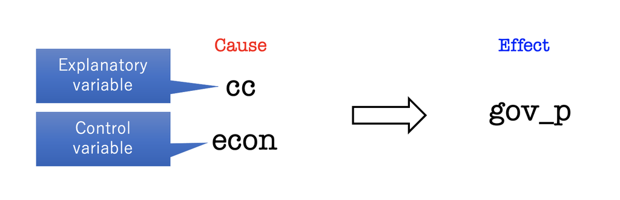

## 4.1 Six steps in Multiple Regression

1. Draw a scatter plot between X and Y
2. Sample Regression Function formula
3. Partial regression coefficient（$α, β_1, β_2$)
4. `F test`
5. Adjusted Coefficient of Determination ($Adjusted R^2$)
6. Standard partial regression coefficient ($β$)

### (1) Draw a scatter plot between X and Y

- Check the data we use

```r
DT::datatable(putnam)
```

|  | region | gov_p | cc | econ | location |
| --- | --- | --- | --- | --- | --- |
| 1 | Ab | 7.5 | 8 | 7 | south |
| 2 | Ba | 7.5 | 4 | 3 | south |
| 3 | Cl | 1.5 | 1 | 3 | south |
| 4 | Cm | 2.5 | 2 | 6.5 | south |
| 5 | Em | 16 | 18 | 13 | north |
| 6 | Fr | 12 | 17 | 14.5 | north |
| 7 | La | 10 | 13 | 12.5 | north |
| 8 | Li | 11 | 16 | 15.5 | north |
| 9 | Lo | 11 | 17 | 19 | north |
| 10 | Ma | 9 | 15.5 | 10.5 | north |

[output cut: 10 more lines]

```r
stargazer(as.data.frame(putnam),
          type = "text",
          title = "Descriptive Statistics on putnam",
          digits = 2)
```

```
Descriptive Statistics on putnam
======================================
Statistic N  Mean  St. Dev. Min   Max
--------------------------------------
gov_p     20 9.15    3.96   1.50 16.00
cc        20 11.35   6.26   1.00 18.00
econ      20 10.43   5.08   2.50 19.00
--------------------------------------
```

- Draw a scatter plot between `gov_p`(Y-axis) and `cc` (X-axis)

```r
plt_1 <- ggplot(putnam, aes(cc, gov_p)) +
  geom_point() +
  labs(x = "Civic Community Index (cc)", y = "Performance of Italian local governments (gov_p)",
         title = "Performance of Italian local governments & Civic Community Index") +
  stat_smooth(method = lm) +
  geom_text(aes(y = gov_p + 0.2, label = region), size = 4, vjust = 0)
```

```r
plt_2 <-  ggplot(putnam, aes(econ, gov_p)) +
  geom_point() +
  labs(x = "Economy Index (econ)", y = "Performance of Italian local governments (gov_p)",
         title = "Performance of Italian local governments & Economy Index") +
  stat_smooth(method = lm) +
  geom_text(aes(y = gov_p + 0.2, label = region), size = 4, vjust = 0)
```

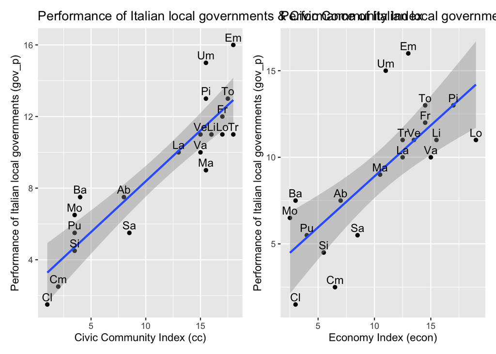

```r
plt_1 + plt_2
```

- We see that both have positive correlation

### (2) Sample Regression Function formula

```r
Model_1 <- lm(gov_p ~ cc, data = putnam)
```

```r
Model_2 <- lm(gov_p ~ econ, data = putnam)
```

```r
stargazer(Model_1, Model_2,
          digits = 3,
          style = "ajps",
          dep.var.caption = "Outcome",
          dep.var.labels = "Gov.Performance",
          title = "Results of Model_1 & Model_2",
          type ="html")
```

|  | **Gov.Performance** |  |
| --- | --- | --- |
|  | **Model 1** | **Model 2** |
| cc | 0.567*** |  |
|  | (0.066) |  |
| econ |  | 0.589*** |
|  |  | (0.120) |
| Constant | 2.711*** | 3.011** |
|  | (0.844) | (1.385) |
| N | 20 | 20 |
| R-squared | 0.806 | 0.572 |
| Adj. R-squared | 0.796 | 0.549 |
| Residual Std. Error (df = 18) | 1.789 | 2.659 |
| F Statistic (df = 1; 18) | 74.967*** | 24.097*** |
| p < .01; p < .05; p < .1 |  |  |

- `Stargazer()` automatically add asterisks to show the level of statistical significant levels (1%, 5%, and 10%)
- `p < .01`（1%）- - - 「$***$」
- `p < .05`（5%）- - - 「$**$」
- `p < .1` （10%）- - - 「$*$」

**Results (`Model_1`)**

- **Coefficient on `cc` (.567):**
- When `cc` increases one unit, then `gov_p` increases by .567 points
- What we want to know it if this is the case in population, too.
- **Three asterisks on the coefficient of `cc`**  
  → We can reject the null hypothesis (coefficient on `cc` = 0 in population) with 99% confidence interval  
  → Statistically significant with the 1% significant level

**Results (`Model_2`)**

- **Coefficient on `econ` (.589):**
- When `econ` increases one unit, then `gov_p` increases by .589 points
- What we want to know it if this is the case in population, too.
- **Three asterisks on the coefficient of `econ`**  
  → We can reject the null hypothesis (coefficient on `cc` = 0 in population) with 99% confidence interval  
  → Statistically significant with the 1% significant level

#### Both `cc` and `econ` are statistically significant

**Note**

- If you want to check `t-value` and `p-value`, you should use `summary()` or `tidy()` as follows:

```r
tidy(Model_1, conf.int = TRUE)
```

```
# A tibble: 2 × 7
  term        estimate std.error statistic      p.value conf.low conf.high
  <chr>          <dbl>     <dbl>     <dbl>        <dbl>    <dbl>     <dbl>
1 (Intercept)    2.71     0.844       3.21 0.00485         0.937     4.49
2 cc             0.567    0.0655      8.66 0.0000000781    0.430     0.705
```

```r
tidy(Model_2, conf.int = TRUE)
```

```
# A tibble: 2 × 7
  term        estimate std.error statistic  p.value conf.low conf.high
  <chr>          <dbl>     <dbl>     <dbl>    <dbl>    <dbl>     <dbl>
1 (Intercept)    3.01      1.38       2.17 0.0433      0.102     5.92
2 econ           0.589     0.120      4.91 0.000113    0.337     0.841
```

### (3) Partial regression coefficient (α, β1, β2)

```r
Model_3 <- lm(gov_p ~ cc + econ, data = putnam)
```

```r
stargazer(Model_1, Model_2, Model_3,
          digits = 3,
          style = "ajps",
          dep.var.caption = "Outcome",
          dep.var.labels = "Gov.Performance",
          title = "Results of Model_1 & Model_2 & Model_3",
          type ="html")
```

|  | **Gov.Performance** |  |  |
| --- | --- | --- | --- |
|  | **Model 1** | **Model 2** | **Model 3** |
| cc | 0.567*** |  | 0.754*** |
|  | (0.066) |  | (0.152) |
| econ |  | 0.589*** | -0.253 |
|  |  | (0.120) | (0.187) |
| Constant | 2.711*** | 3.011** | 3.236*** |
|  | (0.844) | (1.385) | (0.912) |
| N | 20 | 20 | 20 |
| R-squared | 0.806 | 0.572 | 0.825 |
| Adj. R-squared | 0.796 | 0.549 | 0.805 |
| Residual Std. Error | 1.789 (df = 18) | 2.659 (df = 18) | 1.749 (df = 17) |
| F Statistic | 74.967*** (df = 1; 18) | 24.097*** (df = 1; 18) | 40.126*** (df = 2; 17) |
| p < .01; p < .05; p < .1 |  |  |  |

**Sample Regression Function formula on Model_3**

$$\hat{gov_p}\ = 3.236 + 0.754cc -
0.253econ$$

Interpretation :Model_2, Model_2, and Model_3

- In Model_1, `cc` is statistically significant.
- In Model_2, `econ` is statistically significant.
- However, in Model_3, `cc` is statistically significant, but `econ` is not.  
  **Why?**  
  → The relationship between `gov_p` and `econ` is spurious correlation
- Coefficient on `cc` (.754):
- When `cc` increases one unit, then `gov_p` increases by .754 points  
  → Statistically significant with the 1% significant level

### (4) F test

- An F-test is any statistical test in which the test statistic has an F-distribution under the null hypothesis.
- It is most often used when comparing statistical models that have been fitted to a data set, in order to identify the model that best fits the population from which the data were sampled.
- Check the values on F-statistics on `Model_3`

```
 F-statistic: 40.13 on 2 and 17 DF,  p-value: 3.645e-07
```

- `F-statistic` enables us to test whether the coefficient of `cc` and `econ` are simultaneously equal to 0
- **Null hypothesis:** the coefficient of `cc` and `econ` are simultaneously equal to 0
- `F-statistic` = 40.13, `p-value` = 3.645e-07  
  → We can reject the null hypothesis.
- Statistically significant with the 1% significant level → We can conclude that this is an appropriate model

### (5) Adjusted Coefficient of Determination ($adjR^2$)

- In multiple regression, you use $adjR^2$ instead of $R^2$
- Check the values on F-statistics on `Model_3`

```
 Adjusted R-squared:  0.805
```

- 80.5% of the variance of `gov_p` is explained by `cc` and `econ` in Model_3  
  → The other 19.5% remained unexplained

### (6) Standard partial regression coefficient ($β$)

- Usually, the unit of each variable differs, such as `cm`, `kg`, `US dollors`, `yen`, `%`, etc.  
  → It is not possible to see how each variable has an impact on the ourcome over the other variables by simply comparing the size of coefficient.
- By comparing the size of $β$ (`Standardized Beta Coefficient`), we can compare the relative impact of each variable on the outcome.

```r
library("QuantPsyc")
```

```r
Model_3 <- lm(gov_p ~ cc + econ, data = putnam)
lm.beta(Model_3)
```

```
        cc       econ
 1.1932019 -0.3255233
```

Interpretation of β (Model_3)

- The coefficient (1.1932019) → when `cc` increases one standard deviation, `gov_p` increases its standard deviation by 1.19  
  → Statistically significant with the 1% significant level
- The coefficient (-0.3255233) → when `econ` increases one standard deviation, `gov_p` decreases its standard deviation by 0.33  
  → Not statistically significant

### 4.2.8 How to present regression results

**Tables**

```r
stargazer(Model_1, Model_2, Model_3,
          digits = 3,
          style = "ajps",
          dep.var.caption = "Outcome",
          dep.var.labels = "Gov.Performance",
          title = "Results of Model_1 & Model_2 & Model_3",
          type ="html")
```

|  | **Gov.Performance** |  |  |
| --- | --- | --- | --- |
|  | **Model 1** | **Model 2** | **Model 3** |
| cc | 0.567*** |  | 0.754*** |
|  | (0.066) |  | (0.152) |
| econ |  | 0.589*** | -0.253 |
|  |  | (0.120) | (0.187) |
| Constant | 2.711*** | 3.011** | 3.236*** |
|  | (0.844) | (1.385) | (0.912) |
| N | 20 | 20 | 20 |
| R-squared | 0.806 | 0.572 | 0.825 |
| Adj. R-squared | 0.796 | 0.549 | 0.805 |
| Residual Std. Error | 1.789 (df = 18) | 2.659 (df = 18) | 1.749 (df = 17) |
| F Statistic | 74.967*** (df = 1; 18) | 24.097*** (df = 1; 18) | 40.126*** (df = 2; 17) |
| p < .01; p < .05; p < .1 |  |  |  |

**Caterpillar plots**  
**(1) `sjPlot`**

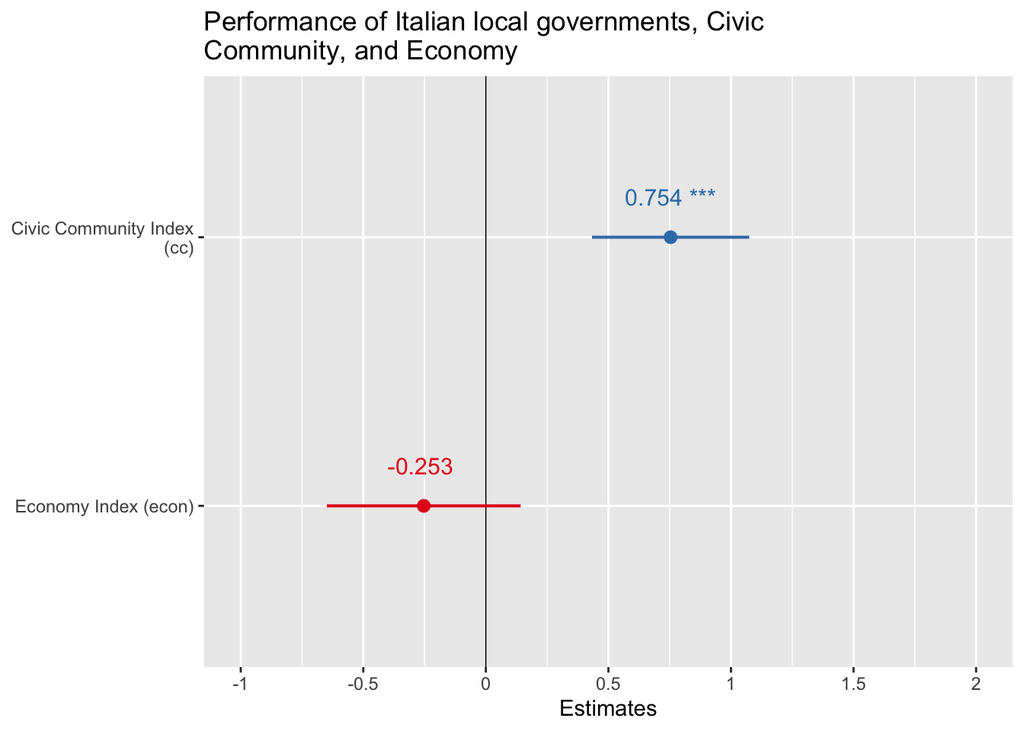

```r
coef_sjplot <- sjPlot::plot_model(Model_3,
                          show.values = T,
                          show.p = T,
                          vline.color = "black",
                          order.terms = c(1, 2),
                          axis.labels = c("Economy Index (econ)", "Civic Community Index (cc)"),
                          axis.title = "Estimates", title = "Performance of Italian local governments, Civic Community, and Economy",
                          digits = 3)

coef_sjplot
```

**【How to interpret sjPlot】**：

- dot (●) is the estimate (= coefficient) for each explanatory variable
- Holizontal lines (blue and red) show the 95% confidence intervals with `α = 0.05 (= 5%)`
- **Blue line**・・・The blue line does not cross the black vertical line  
  → Statistically significant with 5% significant level
- **Red line**・・・The blue line does cross the black vertical line  
  → Not statistically significant with 5% significant level

**(2) `jtools`**

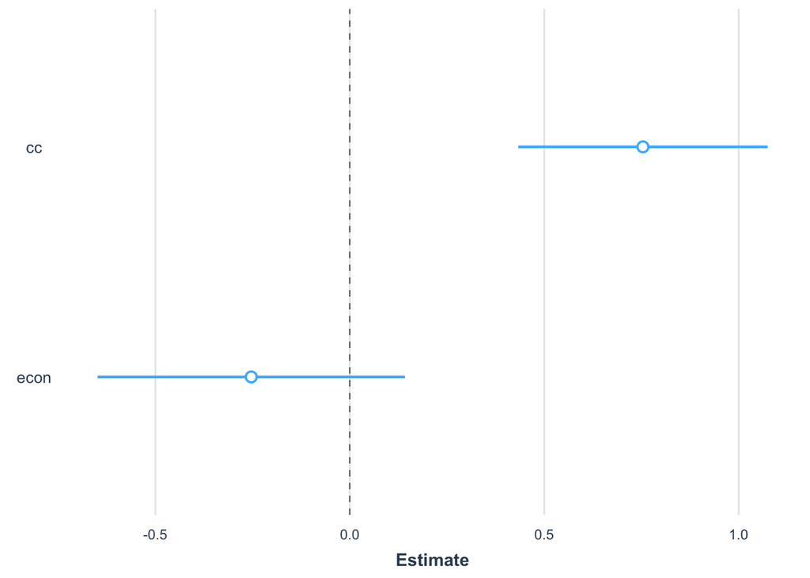

```r
jtools::plot_summs(Model_3)
```

# 5. Excercise

### Excercise 5.1

- Download hr96-24.csv
- Japanese lower house election results (1996-2024)
- Put the file (hr96-24.csv) into `data` folder in your `RProject` folder
- Load the data and name it `hr`

```r
hr <- read_csv("data/hr96-24.csv",
               na = ".")
```

- Check the variable names in `hr`

```r
names(hr)
```

```
 [1] "year"          "pref"          "ku"            "kun"
 [5] "wl"            "rank"          "nocand"        "seito"
 [9] "j_name"        "gender"        "name"          "previous"
[13] "age"           "exp"           "status"        "vote"
[17] "voteshare"     "eligible"      "turnout"       "seshu_dummy"
[21] "jiban_seshu"   "nojiban_seshu"
```

[output not shown]

- Select the 2009 election data from `hr96-24.csv`, and answer the following questions.

**Q1**: Using `seito` variable, make a party variable (DPJ dummy: `dpj`) where 民主党 = 1, others = 0. Add `dpj` to the dataframe, `hr`, as a new variable.

**Q2**: Using `exp` variable, make a new variable (`expm`) where the unit is not “Yen” but “million Yen”. Add `expm` to the dataframe, `hr`, as a new variable.

**Q3**: Using `status` variable, make a new variable, `inc`, where incumbent = 1, challenger and former incumbent = 0. Add `inc` to the dataframe, `hr`, as a new variable.

**Q4**: Show the descriptive statistics of `hr` using `stargazer` package.

**Q5**: Draw a scatter plot between `expm` (x-axis) and `voteshare` (y-axis)

**Q6**: Briely explain the relationship between `expm` (x-axis) and `voteshare` (y-axis)

**Q7**: Suppose you want to know whether campaign money (`expm`) affects votes (`voteshare`).

○ Explanatory Variable — `expm`  
○ Response Variable — `voteshare`

- Select eight control variables from the list below, run a multiple regression, and show the results using `summary()`, `tidy()`, and `stargazer` package.
- You need to briefly explain why you think the eight control variables you select affect `voteshare.`

[output not shown]

**Q8**: Present your statistical results using `sjPlot` or `jtools`.

**Q9**: Interpret the results of multiple regression analysis.

**References**

飯田健『計量政治分析』共立出版、2013年.

ロバート・パットナム（河田潤ー訳）『哲学する民主主義』NTT 出版、2001年.

森田 果『実証分析入門』日本評論社、2014年.

[宋財泫 (Jaehyun Song)・矢内勇生 (Yuki Yanai)「私たちのR: ベストプラクティスの探究」](https://www.jaysong.net/RBook/)

[土井翔平（北海道大学公共政策大学院）「Rで計量政治学入門」](https://shohei-doi.github.io/quant_polisci/data-import.html)

[矢内勇生（高知工科大学）授業一覧](http://yukiyanai.github.io/teaching/)

浅野正彦, 矢内勇生.『Rによる計量政治学』オーム社、2018年

浅野正彦, 中村公亮.『初めてのRStudio』オーム社、2018年

Winston Chang, R Graphics Cookbook, O’Reilly Media, 2012.

Kieran Healy, DATA VISUALIZATION, Princeton, 2019

Kosuke Imai, Quantitative Social Science: An Introduction, Princeton University Press, 2017